# DPA Project

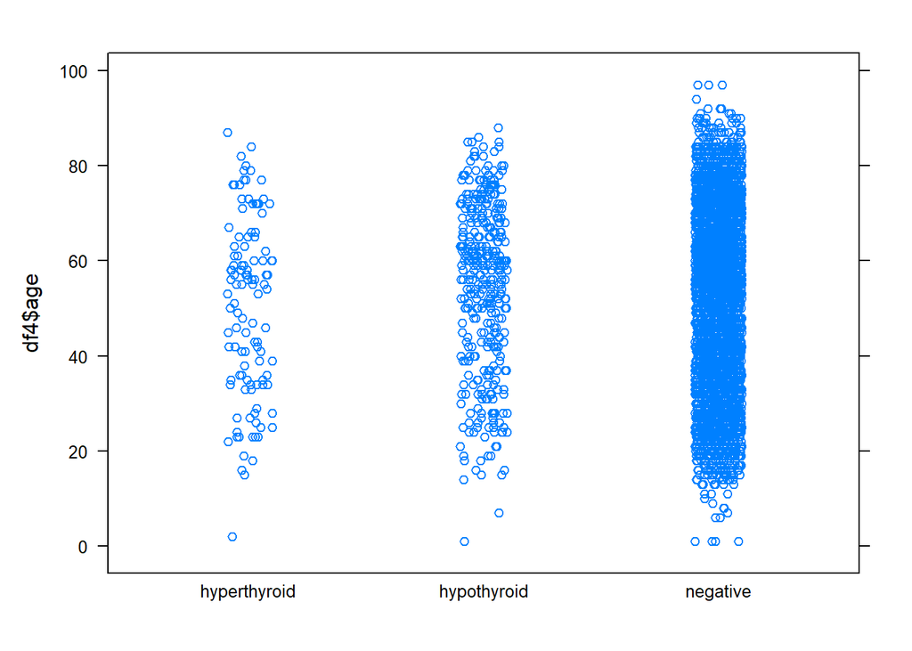

```r
stripplot(df4$age~df4$target,linewidth = 0.6, jitter = 0.3) #newly added line
```

#pair plots

```r
pair_df = data.frame(c( 'TSH', 'T3', 'TT4', 'T4U', 'FTI', 'target'))
length(pair_df)
```

```
## [1] 1
```

#Pairs for age

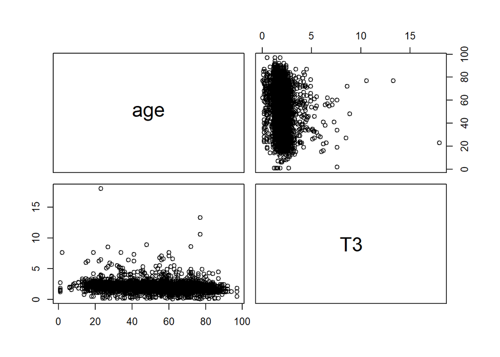

```r
pairs(age~T3,data = df4)
```

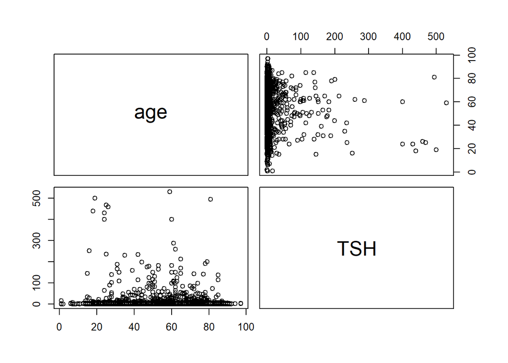

```r
pairs(age~TSH,data = df4)
```

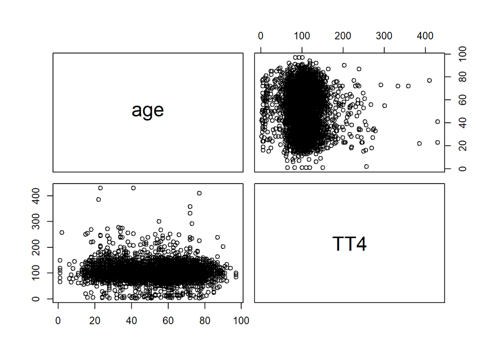

```r
pairs(age~TT4,data = df4)
```

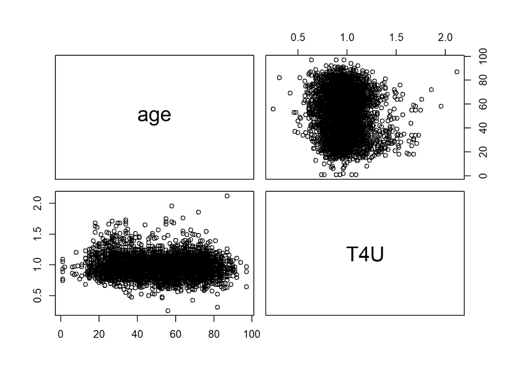

```r
pairs(age~T4U,data = df4)
```

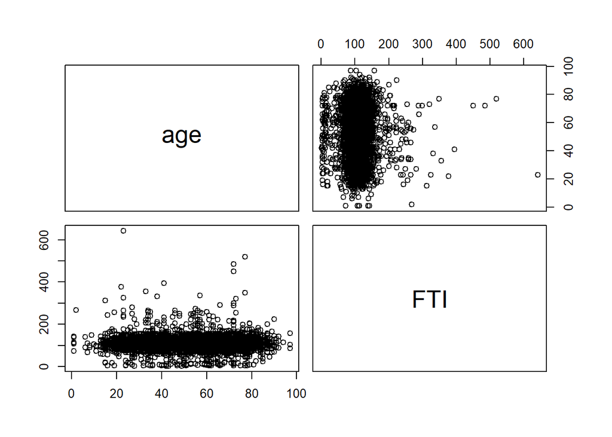

```r
pairs(age~FTI,data = df4)
```

#Pairs for T3

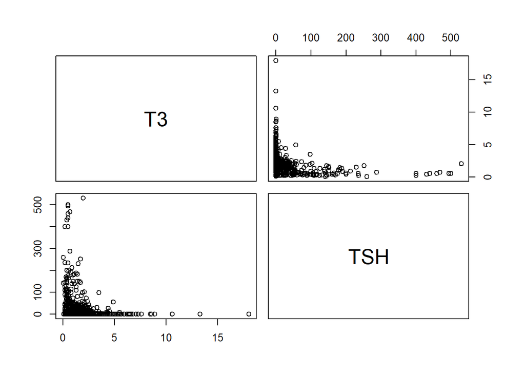

```r
pairs(T3~TSH,data = df4)
```

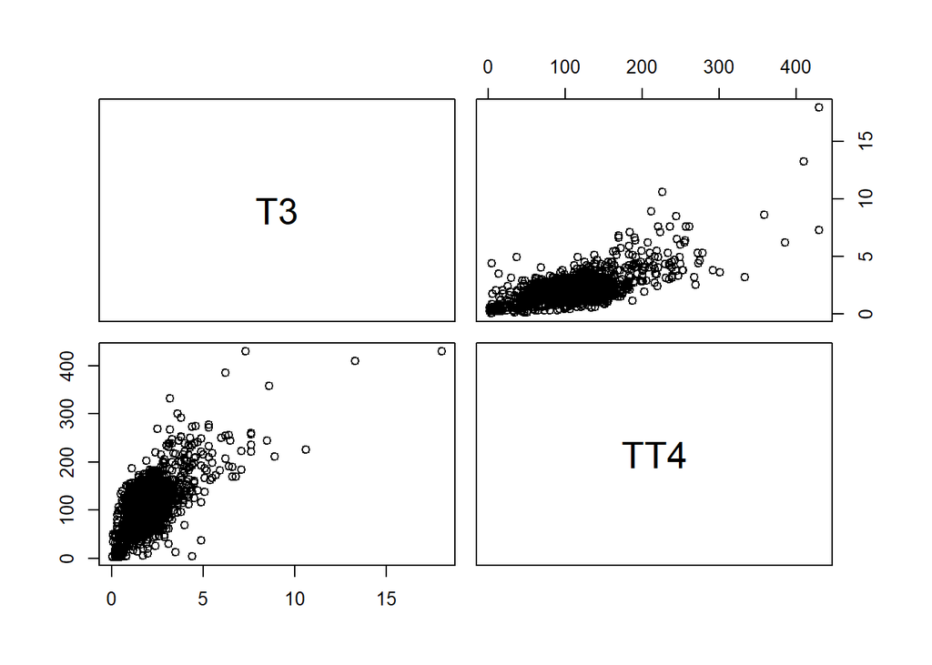

```r
pairs(T3~TT4,data = df4)
```

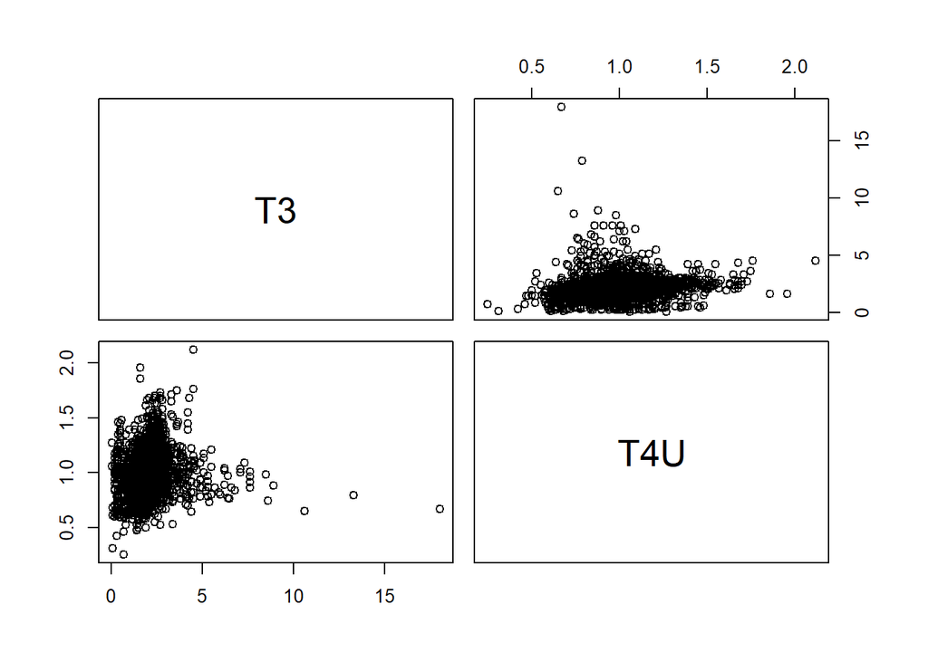

```r
pairs(T3~T4U,data = df4)
```

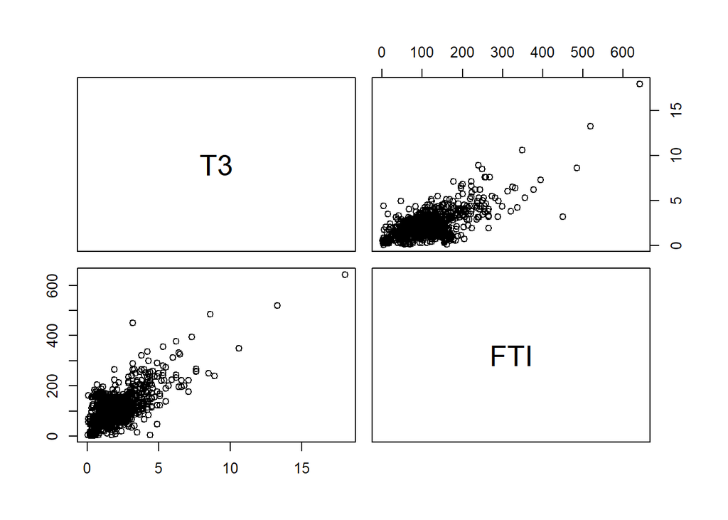

```r
pairs(T3~FTI,data = df4)
```

#Pairs for rest of the features

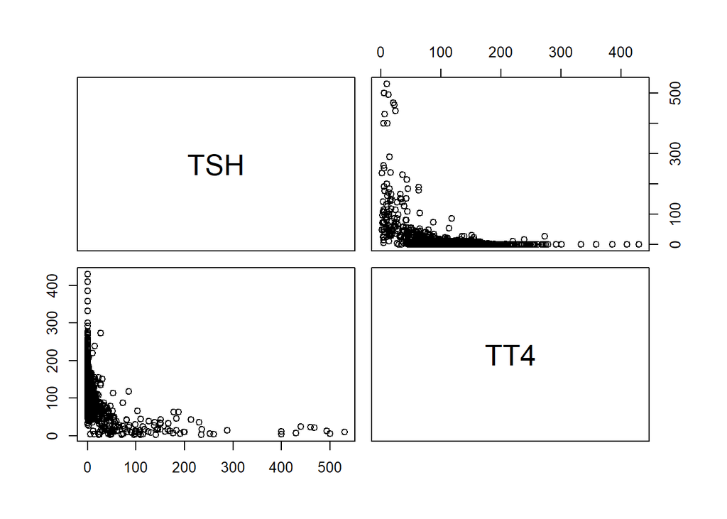

```r
pairs(TSH~TT4,data = df4)
```

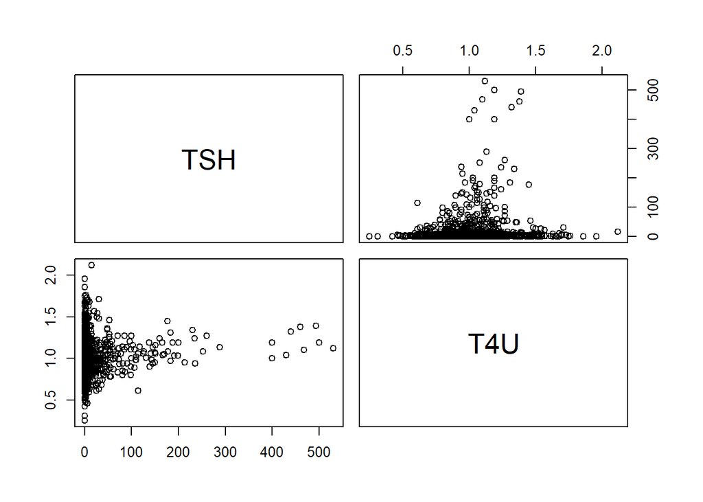

```r
pairs(TSH~T4U,data = df4)
```

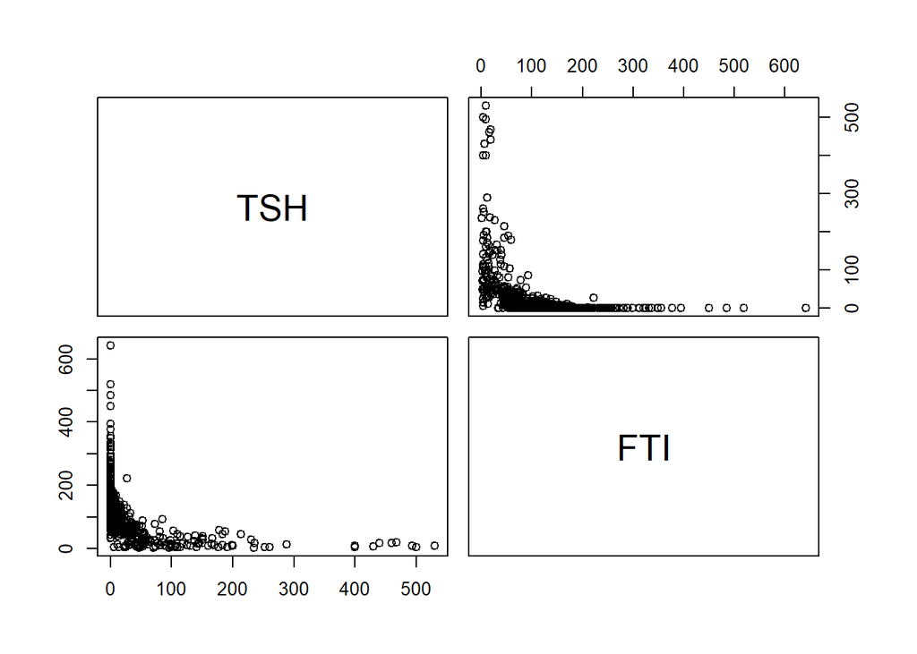

```r
pairs(TSH~FTI,data = df4)
```

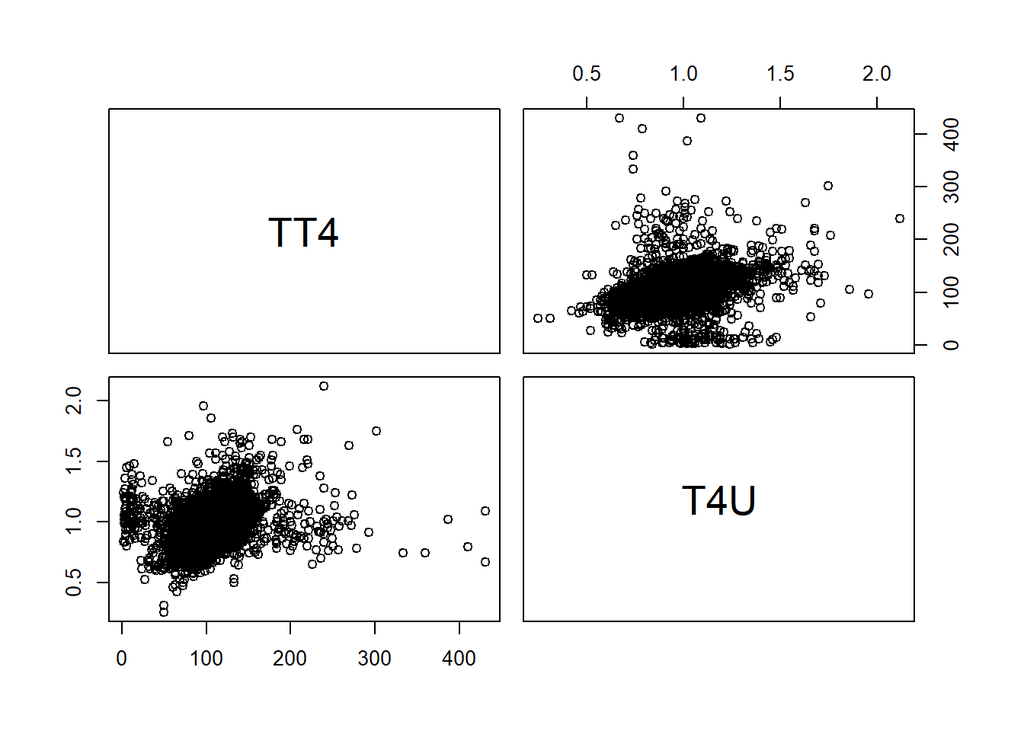

```r
pairs(TT4~T4U,data = df4)
```

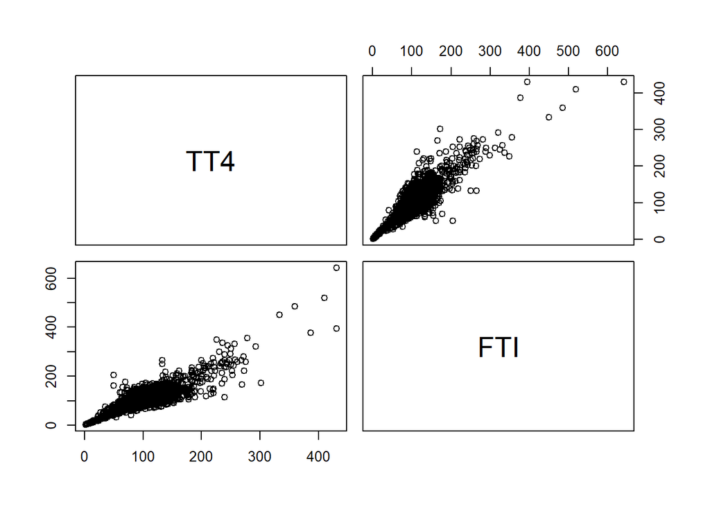

```r
pairs(TT4~FTI,data = df4)
```

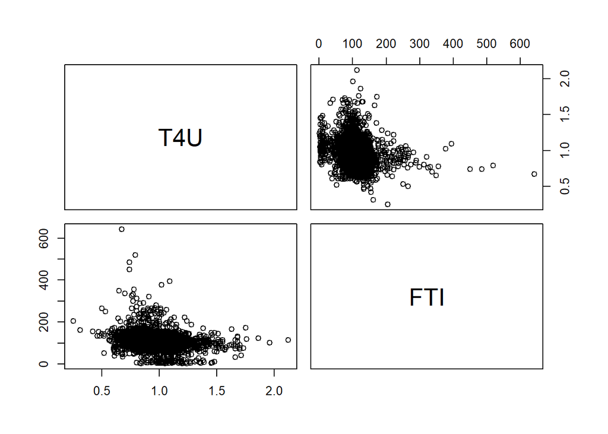

```r
pairs(T4U~FTI,data = df4)
```

```r
typeof(df4$sex)
```

```
## [1] "character"
```

```r
sex = as.numeric(df4$sex)
typeof(sex)
```

```
## [1] "double"
```

```r
typeof(df4$age)
```

```
## [1] "double"
```

```r
#lapply(df4,function(x) { length(which(is.na(x)))})
```

```r
#install.packages("corrplot")
library(corrplot)
typeof(df3$T3)
```

```
## [1] "double"
```

```r
T3 = data.frame(df3$T3)
typeof(T3)
```

```
## [1] "list"
```

#correlation matrix

```r
cor_df = cor(df4[,c('TSH', 'T3', 'TT4', 'T4U', 'FTI','age')])

View(df4)
```

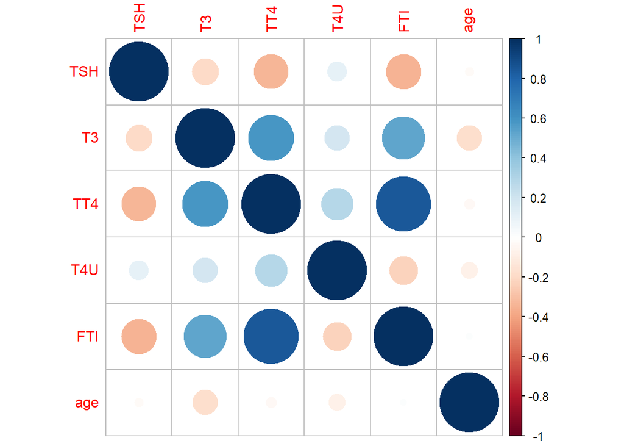

```r
#cor(df4)
corrplot(cor_df)
```

#converting all logical columns to numeric for plotting correlation

```r
cols <- sapply(df4, is.logical)
df4[,cols] <- lapply(df4[,cols], as.numeric)
head(df4)
```

| age | sex | on_thyroxine | query_on_thyroxine | on_antithyroid_meds | sick | pregnant | thyroid_surgery | I131_treatment | query_hypothyroid | query_hyperthyroid | lithium | goitre | tumor | hypopituitary | psych | TSH | T3 | TT4 | T4U | FTI | target |
| --- | --- | --- | --- | --- | --- | --- | --- | --- | --- | --- | --- | --- | --- | --- | --- | --- | --- | --- | --- | --- | --- |
| 36 | F | 0 | 0 | 0 | 0 | 0 | 0 | 0 | 1 | 1 | 0 | 0 | 0 | 0 | 0 | 1.50 | 2.4 | 90 | 1.06 | 85 | negative |
| 40 | F | 0 | 0 | 0 | 0 | 0 | 0 | 0 | 0 | 0 | 0 | 0 | 0 | 0 | 0 | 1.20 | 2.3 | 104 | 1.08 | 96 | negative |
| 40 | F | 0 | 0 | 0 | 0 | 0 | 0 | 0 | 0 | 0 | 0 | 0 | 0 | 0 | 0 | 5.90 | 2.1 | 88 | 0.84 | 105 | negative |
| 77 | F | 0 | 0 | 0 | 0 | 0 | 0 | 0 | 0 | 0 | 0 | 0 | 0 | 0 | 0 | 0.05 | 2.4 | 107 | 1.13 | 95 | negative |
| 51 | F | 0 | 0 | 0 | 0 | 0 | 0 | 0 | 0 | 0 | 0 | 0 | 0 | 0 | 0 | 0.05 | 2.1 | 93 | 0.87 | 106 | negative |
| 56 | M | 0 | 0 | 0 | 0 | 0 | 0 | 0 | 0 | 0 | 0 | 0 | 0 | 0 | 0 | 0.20 | 1.6 | 80 | 0.62 | 129 | negative |

```r
View(df4)
```

```r
cor_df = cor(df4[,c('TSH', 'T3', 'TT4', 'T4U', 'FTI','age','pregnant')])

View(df4)
```

```r
drop <- c("sex","target")
df5 = df4[,!(names(df4) %in% drop)]
View(df5)
```

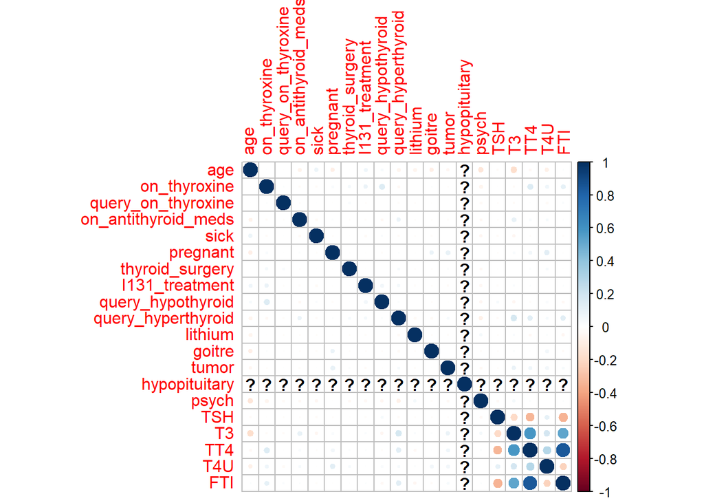

```r
#cor(df5)
corrplot(cor(df5))
```

so even after analysis of all the points in the dataset it is pretty much clear that all the features are not strongly correlated rather only a set of them are.

#newly added

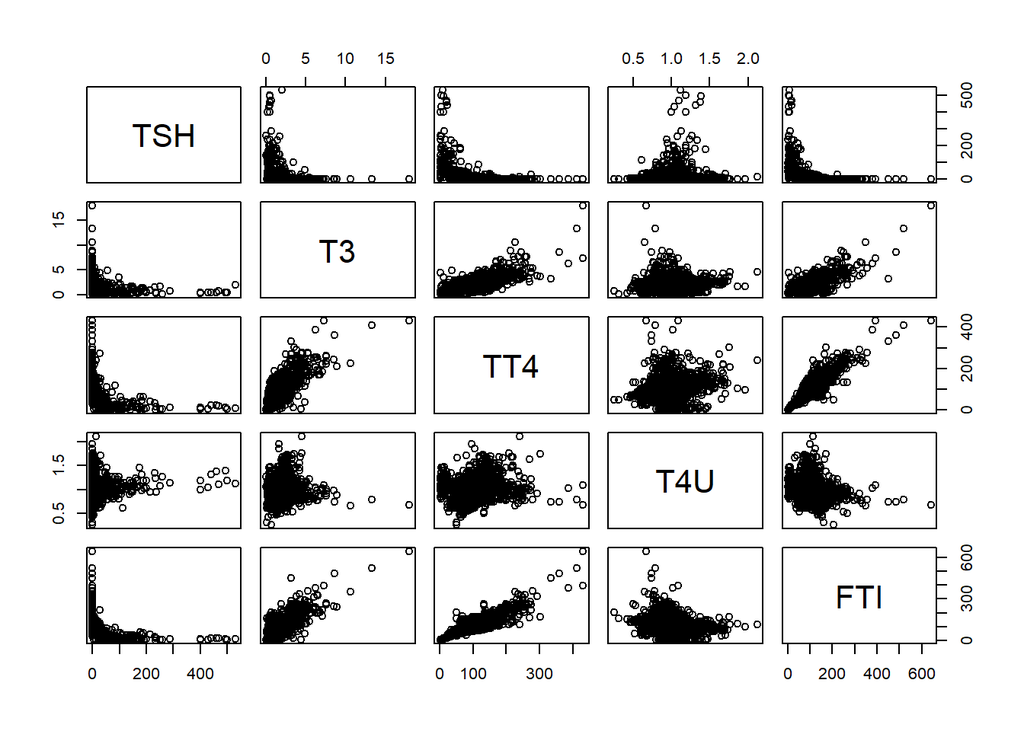

```r
plot(df5[,16:20])
```

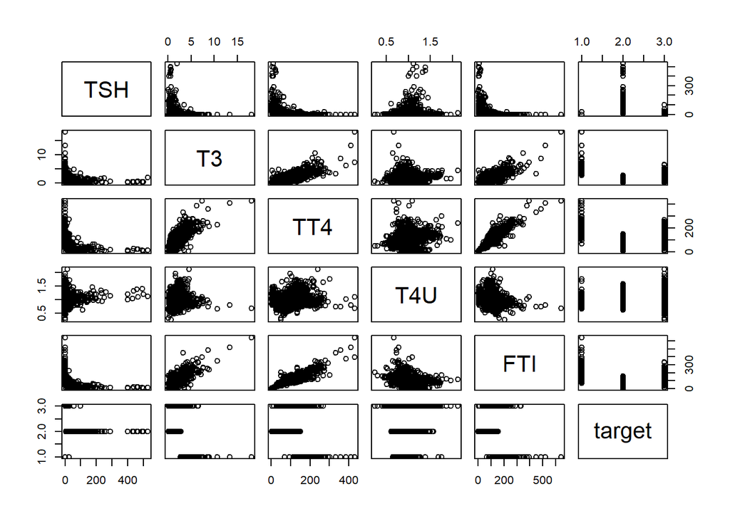

```r
drop <- c("sex")
u_newdf = df4[,!(names(df4) %in% drop)]


plot(u_newdf[,16:21])
```

# data splitting and classification

```r
#install.packages("e1071")
#install.packages("caTools")
#install.packages("class")
```

```r
library(e1071)
library(caTools)
library(class)
head(df4)
```

| age | sex | on_thyroxine | query_on_thyroxine | on_antithyroid_meds | sick | pregnant | thyroid_surgery | I131_treatment | query_hypothyroid | query_hyperthyroid | lithium | goitre | tumor | hypopituitary | psych | TSH | T3 | TT4 | T4U | FTI | target |
| --- | --- | --- | --- | --- | --- | --- | --- | --- | --- | --- | --- | --- | --- | --- | --- | --- | --- | --- | --- | --- | --- |
| 36 | F | 0 | 0 | 0 | 0 | 0 | 0 | 0 | 1 | 1 | 0 | 0 | 0 | 0 | 0 | 1.50 | 2.4 | 90 | 1.06 | 85 | negative |
| 40 | F | 0 | 0 | 0 | 0 | 0 | 0 | 0 | 0 | 0 | 0 | 0 | 0 | 0 | 0 | 1.20 | 2.3 | 104 | 1.08 | 96 | negative |
| 40 | F | 0 | 0 | 0 | 0 | 0 | 0 | 0 | 0 | 0 | 0 | 0 | 0 | 0 | 0 | 5.90 | 2.1 | 88 | 0.84 | 105 | negative |
| 77 | F | 0 | 0 | 0 | 0 | 0 | 0 | 0 | 0 | 0 | 0 | 0 | 0 | 0 | 0 | 0.05 | 2.4 | 107 | 1.13 | 95 | negative |
| 51 | F | 0 | 0 | 0 | 0 | 0 | 0 | 0 | 0 | 0 | 0 | 0 | 0 | 0 | 0 | 0.05 | 2.1 | 93 | 0.87 | 106 | negative |
| 56 | M | 0 | 0 | 0 | 0 | 0 | 0 | 0 | 0 | 0 | 0 | 0 | 0 | 0 | 0 | 0.20 | 1.6 | 80 | 0.62 | 129 | negative |

```r
df6 = subset (df4,select = c('TSH', 'T3', 'TT4', 'T4U', 'FTI','age','target'))
View(df6)
```

```r
set.seed(1)

index = round(nrow(df6)*0.2,digits=0)

test.indices = sample(1:nrow(df6), index)

#80% training set
df6.train=df6[-test.indices,]
#20% test set
df6.test=df6[test.indices,]
```

```r
library('dplyr')
#Select the training set except the DV
YTrain = df6.train$target
XTrain = df6.train %>% select(-target)
# Select the test set except the DV
YTest = df6.test$target
XTest = df6.test %>% select(-target)
```

#error function

```r
calc_error_rate <- function(predicted.value, true.value){
 return(mean(true.value!=predicted.value))
}
```

```r
#install.packages('reshape2')
library('reshape2')
```

```r
library('class')
nfold = 10
set.seed(1)
# cut() divides the range into several intervals
folds = seq.int(nrow(df6.train)) %>%
     cut(breaks = nfold, labels=FALSE) %>%
     sample
do.chunk <- function(chunkid, folddef, Xdat, Ydat, k){
     train = (folddef!=chunkid)# training index
Xtr = Xdat[train,] # training set by the index
Ytr = Ydat[train] # true label in training set
Xvl = Xdat[!train,] # test set
Yvl = Ydat[!train] # true label in test set
predYtr = knn(train = Xtr, test = Xtr, cl = Ytr, k = k) # predict training labels
predYvl = knn(train = Xtr, test = Xvl, cl = Ytr, k = k) # predict test labels
data.frame(fold =chunkid, # k folds
train.error = calc_error_rate(predYtr, Ytr),#training error per fold
 val.error = calc_error_rate(predYvl, Yvl)) # test error per fold
 }
# set error.folds to save validation errors
error.folds=NULL
# create a sequence of data with an interval of 10
kvec = c(1, seq(10, 50, length.out=5))
set.seed(1)
for (j in kvec){
 tmp = lapply(1:nfold, do.chunk, # apply do.function to each fold
 folddef=folds, Xdat=XTrain, Ydat=YTrain, k=j) # required arguments
 tmp$neighbors = j # track each value of neighbors
 error.folds = rbind(error.folds, tmp) # combine the results
 }
#melt() in the package reshape2 melts wide-format data into long-format data
errors = melt(error.folds, id.vars=c("fold","neighbors"), value.name= "error")
errors
```

| Var1 | Var2 | error | None | None | None | None | None | None | None | None | None | None |
| --- | --- | --- | --- | --- | --- | --- | --- | --- | --- | --- | --- | --- |
| tmp |  |  |  |  |  |  |  |  |  |  |  |  |
| tmp |  |  |  |  |  |  |  |  |  |  |  |  |
| tmp |  |  |  |  |  |  |  |  |  |  |  |  |
| tmp |  |  |  |  |  |  |  |  |  |  |  |  |
| tmp |  |  |  |  |  |  |  |  |  |  |  |  |
| tmp |  |  |  |  |  |  |  |  |  |  |  |  |
| tmp |  |  |  |  |  |  |  |  |  |  |  |  |
| tmp |  |  |  |  |  |  |  |  |  |  |  |  |
| tmp |  |  |  |  |  |  |  |  |  |  |  |  |
| tmp |  |  |  |  |  |  |  |  |  |  |  |  |

[output cut: 56 more lines]

```r
library('tidyverse')
```

#to find the best value of k

```r
set.seed(20)
pred.YTtrain = knn(train=XTrain, test=XTrain, cl=YTrain, k=20)
knn_traing_error <- calc_error_rate(predicted.value=pred.YTtrain, true.value=YTrain)
knn_traing_error
```

```
## [1] 0.05342282
```

```r
#test error
set.seed(20)
pred.YTest = knn(train=XTrain, test=XTest, cl=YTrain, k=20)
knn_test_error <- calc_error_rate(predicted.value=pred.YTest, true.value=YTest)
knn_test_error
```

```
## [1] 0.05585392
```

```r
#confusion matrix
conf.matrix = table(predicted=pred.YTest, true=YTest)
```

```r
# Test accuracy rate
sum(diag(conf.matrix)/sum(conf.matrix))
```

```
## [1] 0.9441461
```

#box plots

```r
df6 <- df6 %>%
  mutate(target=as_factor(target) )
```

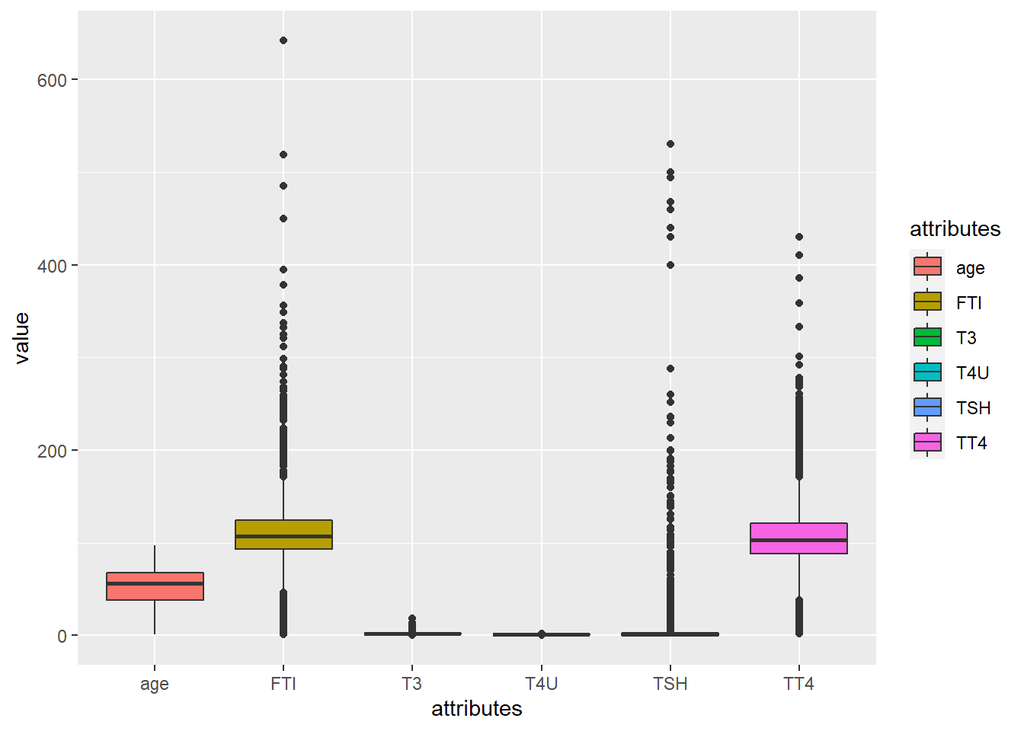

```r
draw_boxplot <- function(){
  df6 %>%
    pivot_longer(1:6, names_to="attributes") %>%
    ggplot(aes(attributes, value, fill=attributes)) +
    geom_boxplot()
}

draw_boxplot()
```

```r
#install.packages('scales')
```

#outliers

```r
library(dplyr)
library(scales)
df6 <- df6 %>%
  mutate(across(FTI, ~squish(.x, quantile(.x, c(0.05, 0.95)))))

df6 <- df6 %>%
  mutate(across(T3, ~squish(.x, quantile(.x, c(0.05, 0.95)))))

df6 <- df6 %>%
  mutate(across(TSH, ~squish(.x, quantile(.x, c(0.05, 0.95)))))

df6 <- df6 %>%
  mutate(across(TT4, ~squish(.x, quantile(.x, c(0.05, 0.95)))))

df6 <- df6 %>%
  mutate(across(T4U, ~squish(.x, quantile(.x, c(0.05, 0.95)))))
```

```r
df6 <- df6 %>%
  mutate(across(1:6, scale))
```

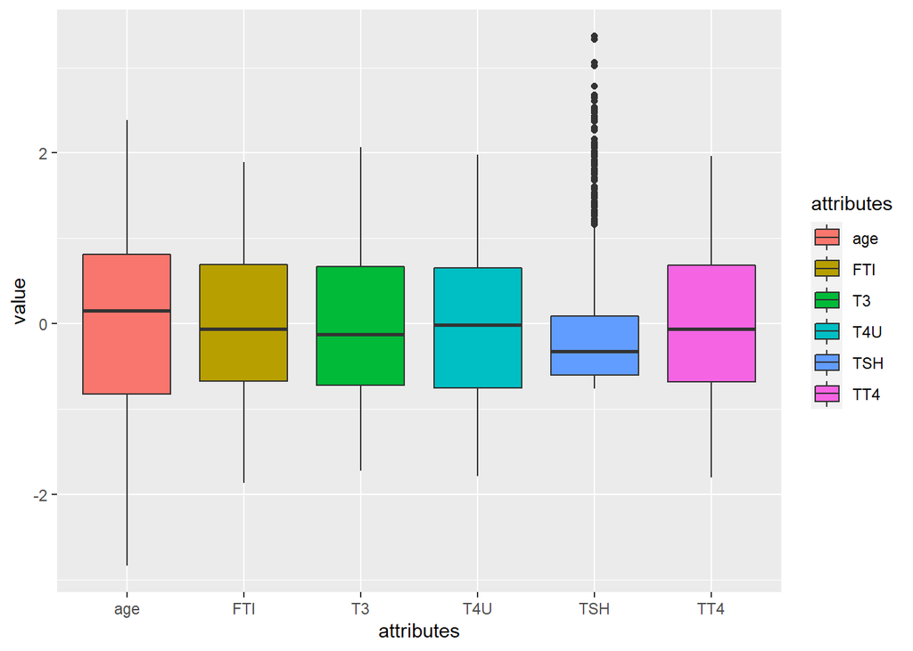

```r
library(tidyverse)
draw_boxplot()
```

#K-NN classifier

```r
library(e1071)
library(caTools)
library(class)




head(df4)
```

| age | sex | on_thyroxine | query_on_thyroxine | on_antithyroid_meds | sick | pregnant | thyroid_surgery | I131_treatment | query_hypothyroid | query_hyperthyroid | lithium | goitre | tumor | hypopituitary | psych | TSH | T3 | TT4 | T4U | FTI | target |
| --- | --- | --- | --- | --- | --- | --- | --- | --- | --- | --- | --- | --- | --- | --- | --- | --- | --- | --- | --- | --- | --- |
| 36 | F | 0 | 0 | 0 | 0 | 0 | 0 | 0 | 1 | 1 | 0 | 0 | 0 | 0 | 0 | 1.50 | 2.4 | 90 | 1.06 | 85 | negative |
| 40 | F | 0 | 0 | 0 | 0 | 0 | 0 | 0 | 0 | 0 | 0 | 0 | 0 | 0 | 0 | 1.20 | 2.3 | 104 | 1.08 | 96 | negative |
| 40 | F | 0 | 0 | 0 | 0 | 0 | 0 | 0 | 0 | 0 | 0 | 0 | 0 | 0 | 0 | 5.90 | 2.1 | 88 | 0.84 | 105 | negative |
| 77 | F | 0 | 0 | 0 | 0 | 0 | 0 | 0 | 0 | 0 | 0 | 0 | 0 | 0 | 0 | 0.05 | 2.4 | 107 | 1.13 | 95 | negative |
| 51 | F | 0 | 0 | 0 | 0 | 0 | 0 | 0 | 0 | 0 | 0 | 0 | 0 | 0 | 0 | 0.05 | 2.1 | 93 | 0.87 | 106 | negative |
| 56 | M | 0 | 0 | 0 | 0 | 0 | 0 | 0 | 0 | 0 | 0 | 0 | 0 | 0 | 0 | 0.20 | 1.6 | 80 | 0.62 | 129 | negative |

```r
#df6 = subset (df4,select = c('TSH', 'T3', 'TT4', 'T4U', 'FTI','age','target'))
#View(df6)
```

```r
set.seed(1)

index = round(nrow(df6)*0.2,digits=0)

test.indices = sample(1:nrow(df6), index)

#80% training set
df6.train=df6[-test.indices,]
#20% test set
df6.test=df6[test.indices,]
```

```r
library('dplyr')
#Select the training set except the DV
YTrain = df6.train$target
XTrain = df6.train %>% select(-target)
# Select the test set except the DV
YTest = df6.test$target
XTest = df6.test %>% select(-target)
```

#error function

```r
calc_error_rate <- function(predicted.value, true.value){
 return(mean(true.value!=predicted.value))
}
```

```r
#install.packages('reshape2')
library('reshape2')
```

```r
library('class')
nfold = 10
set.seed(1)
# cut() divides the range into several intervals
folds = seq.int(nrow(df6.train)) %>%
     cut(breaks = nfold, labels=FALSE) %>%
     sample
do.chunk <- function(chunkid, folddef, Xdat, Ydat, k){
     train = (folddef!=chunkid)# training index
Xtr = Xdat[train,] # training set by the index
Ytr = Ydat[train] # true label in training set
Xvl = Xdat[!train,] # test set
Yvl = Ydat[!train] # true label in test set
predYtr = knn(train = Xtr, test = Xtr, cl = Ytr, k = k) # predict training labels
predYvl = knn(train = Xtr, test = Xvl, cl = Ytr, k = k) # predict test labels
data.frame(fold =chunkid, # k folds
train.error = calc_error_rate(predYtr, Ytr),#training error per fold
 val.error = calc_error_rate(predYvl, Yvl)) # test error per fold
 }
# set error.folds to save validation errors
error.folds=NULL
# create a sequence of data with an interval of 10
kvec = c(1, seq(10, 50, length.out=5))
set.seed(1)
for (j in kvec){
 tmp = lapply(1:nfold, do.chunk, # apply do.function to each fold
 folddef=folds, Xdat=XTrain, Ydat=YTrain, k=j) # required arguments
 tmp$neighbors = j # track each value of neighbors
 error.folds = rbind(error.folds, tmp) # combine the results
 }
#melt() in the package reshape2 melts wide-format data into long-format data
errors = melt(error.folds, id.vars=c("fold","neighbors"), value.name= "error")
errors
```

| Var1 | Var2 | error | None | None | None | None | None | None | None | None | None | None |
| --- | --- | --- | --- | --- | --- | --- | --- | --- | --- | --- | --- | --- |
| tmp |  |  |  |  |  |  |  |  |  |  |  |  |
| tmp |  |  |  |  |  |  |  |  |  |  |  |  |
| tmp |  |  |  |  |  |  |  |  |  |  |  |  |
| tmp |  |  |  |  |  |  |  |  |  |  |  |  |
| tmp |  |  |  |  |  |  |  |  |  |  |  |  |
| tmp |  |  |  |  |  |  |  |  |  |  |  |  |
| tmp |  |  |  |  |  |  |  |  |  |  |  |  |
| tmp |  |  |  |  |  |  |  |  |  |  |  |  |
| tmp |  |  |  |  |  |  |  |  |  |  |  |  |
| tmp |  |  |  |  |  |  |  |  |  |  |  |  |

[output cut: 56 more lines]

```r
library('tidyverse')
```

#to find the best value of k

```r
set.seed(20)
pred.YTtrain = knn(train=XTrain, test=XTrain, cl=YTrain, k=20)
knn_traing_error <- calc_error_rate(predicted.value=pred.YTtrain, true.value=YTrain)
knn_traing_error
```

```
## [1] 0.0295302
```

```r
#test error
set.seed(20)
pred.YTest = knn(train=XTrain, test=XTest, cl=YTrain, k=20)
knn_test_error <- calc_error_rate(predicted.value=pred.YTest, true.value=YTest)
knn_test_error
```

```
## [1] 0.02685285
```

```r
#confusion matrix
conf.matrix = table(predicted=pred.YTest, true=YTest)
```

```r
# Test accuracy rate
sum(diag(conf.matrix)/sum(conf.matrix))
```

```
## [1] 0.9731472
```

#Random Forest

```r
library(randomForest)
library(datasets)
library(caret)
df6$target <- as.factor(df6$target)
table(df6$target)
```

```
##
##     negative  hypothyroid hyperthyroid
##         4165          375          116
```

```r
set.seed(222)
ind <- sample(2, nrow(df6), replace = TRUE, prob = c(0.7, 0.3))
train <- df6[ind==1,]
test <- df6[ind==2,]
```

```r
rf <- randomForest(target~., data=train, proximity=TRUE)
print(rf)
```

```
##
## Call:
##  randomForest(formula = target ~ ., data = train, proximity = TRUE)
##                Type of random forest: classification
##                      Number of trees: 500
## No. of variables tried at each split: 2
##
##         OOB estimate of  error rate: 1.2%
## Confusion matrix:
##              negative hypothyroid hyperthyroid class.error
## negative         2868           5           17 0.007612457
## hypothyroid         0         280            0 0.000000000
## hyperthyroid       17           0           66 0.204819277
```

Out of the bag error rate is 1.23% so the accuracy of the training data is approximately 98%.

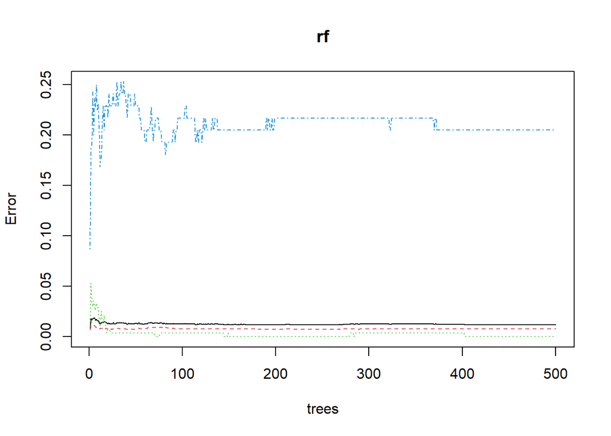

```r
plot(rf)
```

```r
library(tidyverse)
p1 <- predict(rf,train)
confusionMatrix(p1, train$target)
```

```
## Confusion Matrix and Statistics
##
##               Reference
## Prediction     negative hypothyroid hyperthyroid
##   negative         2883           0            0
##   hypothyroid         0         280            0
##   hyperthyroid        7           0           83
##
## Overall Statistics
##
##                Accuracy : 0.9978
##                  95% CI : (0.9956, 0.9991)
##     No Information Rate : 0.8884
##     P-Value [Acc > NIR] : < 2.2e-16
##
##                   Kappa : 0.9895
##
##  Mcnemar's Test P-Value : NA
##
## Statistics by Class:
##
##                      Class: negative Class: hypothyroid Class: hyperthyroid
## Sensitivity                   0.9976            1.00000             1.00000
## Specificity                   1.0000            1.00000             0.99779
## Pos Pred Value                1.0000            1.00000             0.92222
## Neg Pred Value                0.9811            1.00000             1.00000
## Prevalence                    0.8884            0.08607             0.02551
## Detection Rate                0.8863            0.08607             0.02551
## Detection Prevalence          0.8863            0.08607             0.02767
## Balanced Accuracy             0.9988            1.00000             0.99890
```

The accuracy of the training set is 99.78%.

```r
p2 <- predict(rf, test)
confusionMatrix(p2, test$target)
```

```
## Confusion Matrix and Statistics
##
##               Reference
## Prediction     negative hypothyroid hyperthyroid
##   negative         1265           1            5
##   hypothyroid         4          94            0
##   hyperthyroid        6           0           28
##
## Overall Statistics
##
##                Accuracy : 0.9886
##                  95% CI : (0.9815, 0.9935)
##     No Information Rate : 0.9088
##     P-Value [Acc > NIR] : < 2.2e-16
##
##                   Kappa : 0.9335
##
##  Mcnemar's Test P-Value : NA
##
## Statistics by Class:
##
##                      Class: negative Class: hypothyroid Class: hyperthyroid
## Sensitivity                   0.9922            0.98947             0.84848
## Specificity                   0.9531            0.99694             0.99562
## Pos Pred Value                0.9953            0.95918             0.82353
## Neg Pred Value                0.9242            0.99923             0.99635
## Prevalence                    0.9088            0.06771             0.02352
## Detection Rate                0.9016            0.06700             0.01996
## Detection Prevalence          0.9059            0.06985             0.02423
## Balanced Accuracy             0.9726            0.99321             0.92205
```

The accuracy of the Test data set is 98.86%

#Naive Bayes

```r
#install.packages('naivebayes')
#install.packages('psych')
library(naivebayes)
```

```r
library(dplyr)
library(ggplot2)
library(psych)
set.seed(1234)
ind <- sample(2, nrow(df6), replace = T, prob = c(0.8, 0.2))
train <- df6[ind == 1,]
test <- df6[ind == 2,]
```

```r
model <- naive_bayes(target ~ ., data = train, usekernel = T)
model
```

```
##
## ================================== Naive Bayes ==================================
##
##  Call:
## naive_bayes.formula(formula = target ~ ., data = train, usekernel = T)
##
## ---------------------------------------------------------------------------------
##
## Laplace smoothing: 0
##
## ---------------------------------------------------------------------------------
##
##  A priori probabilities:
##
##     negative  hypothyroid hyperthyroid
##   0.89493534   0.08108836   0.02397629
##
## ---------------------------------------------------------------------------------
##
##  Tables:
##
## ---------------------------------------------------------------------------------
##  ::: TSH::negative (KDE)
## ---------------------------------------------------------------------------------
##
## Call:
##  density.default(x = x, na.rm = TRUE)
##
## Data: x (3322 obs.); Bandwidth 'bw' = 0.07791
##
##        x                 y
##  Min.   :-0.9926   Min.   :0.0000173
##  1st Qu.: 0.1560   1st Qu.:0.0024895
##  Median : 1.3047   Median :0.0194210
##  Mean   : 1.3047   Mean   :0.2174102
##  3rd Qu.: 2.4534   3rd Qu.:0.2779217
##  Max.   : 3.6020   Max.   :1.2086752
##
## ---------------------------------------------------------------------------------
##  ::: TSH::hypothyroid (KDE)
```

[output cut: 226 more lines]

```
## Data: x (89 obs.);   Bandwidth 'bw' = 0.2692
##
##        x                  y
##  Min.   :-2.63167   Min.   :0.0001877
##  1st Qu.:-1.29857   1st Qu.:0.0172520
##  Median : 0.03453   Median :0.0608808
##  Mean   : 0.03453   Mean   :0.1871592
##  3rd Qu.: 1.36763   3rd Qu.:0.1310901
##  Max.   : 2.70073   Max.   :1.1698012
##
## ---------------------------------------------------------------------------------
##
## # ... and 1 more table
##
## ---------------------------------------------------------------------------------
```

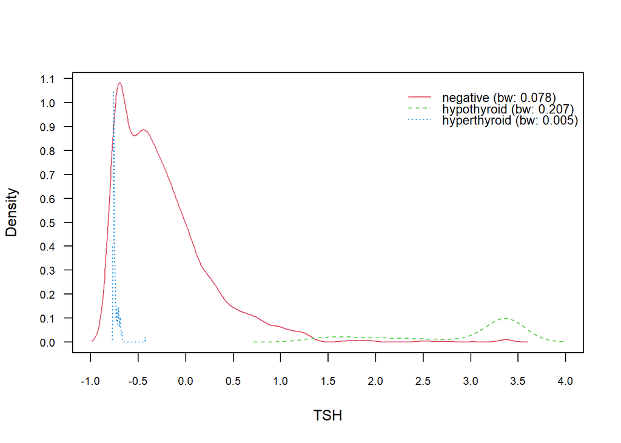

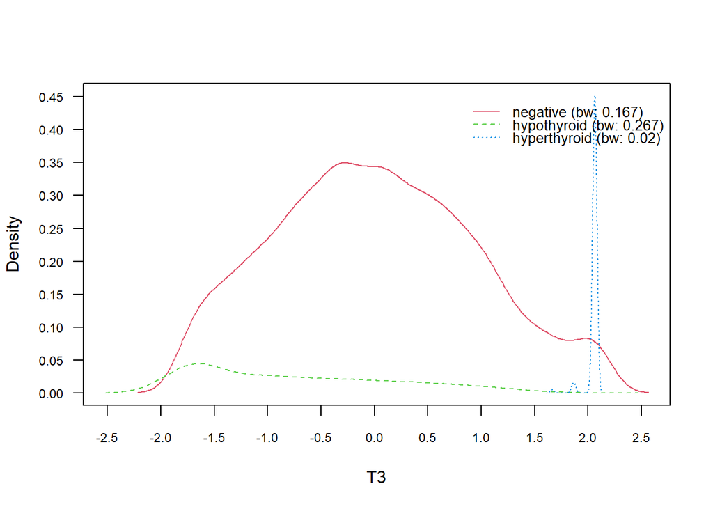

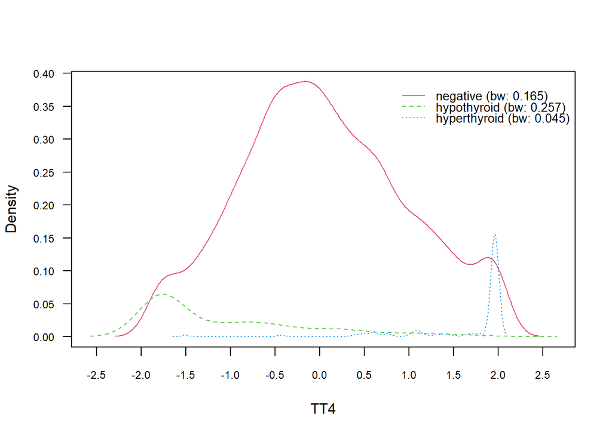

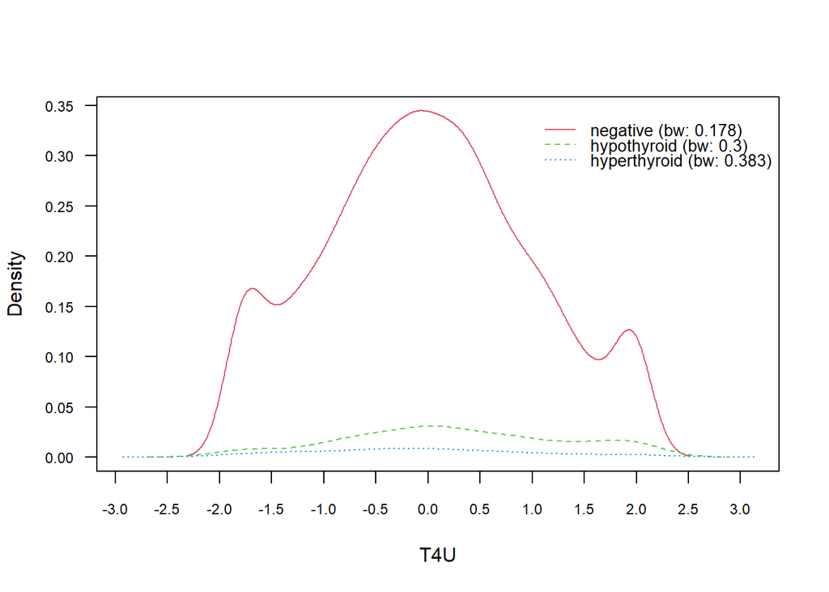

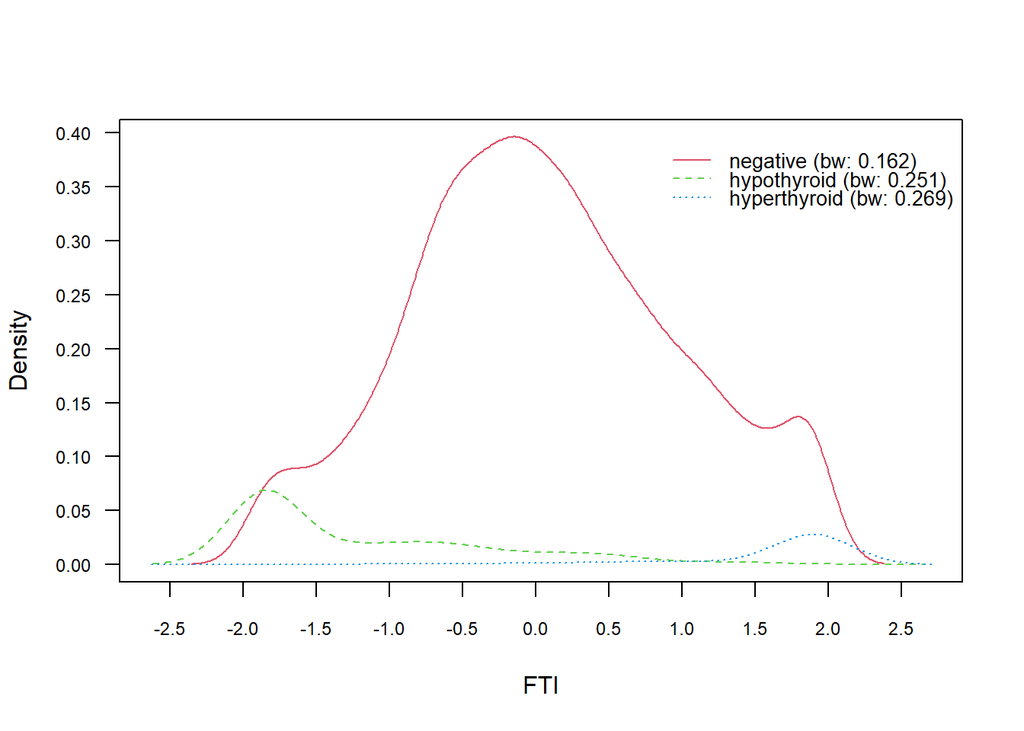

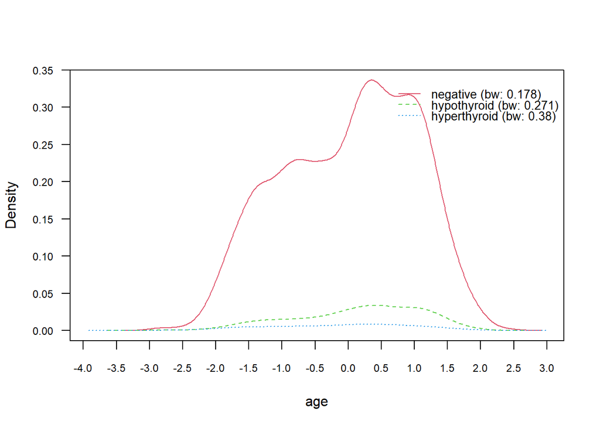

```r
plot(model)
```

```r
p <- predict(model, train, type = 'prob')
head(cbind(p, train))
```

|  | negative | hypothyroid | hyperthyroid | TSH | T3 | TT4 | T4U | FTI | age | target |
| --- | --- | --- | --- | --- | --- | --- | --- | --- | --- | --- |
| 1 | 0.9999754 | 2.460593e-05 | 1.000634e-10 | -0.2580927 | 0.8694115 | -0.60144635 | 0.6493204 | -1.0299687 | -0.9335343 | negative |
| 2 | 0.9999936 | 6.356573e-06 | 3.033909e-10 | -0.3617037 | 0.6702156 | -0.02201834 | 0.7968004 | -0.5446008 | -0.7158674 | negative |
| 3 | 0.9684399 | 3.156015e-02 | 6.558790e-13 | 1.2615344 | 0.2718237 | -0.68422178 | -0.9729591 | -0.1474816 | -0.7158674 | negative |
| 4 | 0.9999902 | 9.833571e-06 | 2.139305e-13 | -0.7588789 | 0.8694115 | 0.10214481 | 1.1655002 | -0.5887252 | 1.2975513 | negative |
| 5 | 0.9999912 | 6.791576e-06 | 1.975044e-06 | -0.7070735 | -0.7241559 | -1.01532350 | -1.7840988 | 0.9115030 | 0.1548001 | negative |
| 6 | 0.9999731 | 2.692890e-05 | 3.218861e-09 | 0.2599620 | 0.0726278 | -0.56005863 | -0.4567792 | -0.3681034 | -0.6070339 | negative |

```r
p1 <- predict(model, train)
(tab1 <- table(p1, train$target))
```

```
##
## p1             negative hypothyroid hyperthyroid
##   negative         3242          38            1
##   hypothyroid        18         263            0
##   hyperthyroid       62           0           88
```

```r
1 - sum(diag(tab1)) / sum(tab1)
```

```
## [1] 0.03205819
```

```r
p2 <- predict(model, test)
(tab2 <- table(p2, test$target))
```

```
##
## p2             negative hypothyroid hyperthyroid
##   negative          825          10            0
##   hypothyroid         3          64            0
##   hyperthyroid       15           0           27
```

```r
1 - sum(diag(tab2)) / sum(tab2)
```

```
## [1] 0.02966102
```

#Regression Model

```r
#Splitting the data using a function from dplyr package
library(caret)

index <- createDataPartition(df6$target, p = .80, list = FALSE)
train <- df6[index,]
test <- df6[-index,]
```

```r
require(nnet)
# Training the multinomial model
multinom_model <- multinom(target ~ ., data = df6)
# Checking the model
summary(multinom_model)
```

```
## Call:
## multinom(formula = target ~ ., data = df6)
##
## Coefficients:
##              (Intercept)       TSH         T3        TT4        T4U        FTI
## hypothyroid    -5.950446  3.272315 -0.6226737 -0.3992114  0.1402094 0.00798443
## hyperthyroid  -18.267085 -1.895759  7.3204066  0.9905980 -0.1632270 0.52340680
##                     age
## hypothyroid  -0.0226490
## hyperthyroid  0.1340127
##
## Std. Errors:
##              (Intercept)       TSH        T3       TT4       T4U       FTI
## hypothyroid    0.3087398 0.1969432 0.1861933 0.4777054 0.3132026 0.4393192
## hyperthyroid   2.8069045 0.8493188 1.3683027 0.4463123 0.2112669 0.4282340
##                    age
## hypothyroid  0.1464183
## hyperthyroid 0.1643227
##
## Residual Deviance: 638.3275
## AIC: 666.3275
```

```r
exp(coef(multinom_model))
```

```
##               (Intercept)        TSH           T3       TT4       T4U      FTI
## hypothyroid  2.604679e-03 26.3723241    0.5365081 0.6708489 1.1505147 1.008016
## hyperthyroid 1.166019e-08  0.1502042 1510.8181077 2.6928443 0.8493984 1.687768
##                    age
## hypothyroid  0.9776056
## hyperthyroid 1.1434073
```

```r
head(round(fitted(multinom_model), 2))
```

```
##   negative hypothyroid hyperthyroid
## 1     1.00        0.00            0
## 2     1.00        0.00            0
## 3     0.86        0.14            0
## 4     1.00        0.00            0
## 5     1.00        0.00            0
## 6     1.00        0.00            0
```

```r
# Predicting the values for train dataset
train$ClassPredicted <- predict(multinom_model, newdata = train)

# Building classification table
tab <- table(train$target, train$ClassPredicted)

# Calculating accuracy - sum of diagonal elements divided by total obs
round((sum(diag(tab))/sum(tab))*100,2)
```

```
## [1] 97.13
```

```r
# Predicting the class for test dataset
test$ClassPredicted <- predict(multinom_model, newdata = test)

# Building classification table
tab <- table(test$target, test$ClassPredicted)
tab
```

```
##
##                negative hypothyroid hyperthyroid
##   negative          823           3            7
##   hypothyroid         9          66            0
##   hyperthyroid        3           0           20
```

```r
round((sum(diag(tab))/sum(tab))*100,2)
```

```
## [1] 97.64
```